# 網頁應用程式1

蔡東樟

Lesson 12

# 什麼是網頁應用程式(WebApp)?

- WebApp是讓網站從單純的呈現資訊，進階為更具功能性/互動性的網站系統。

– 前端：使用HTML/CSS/Java Script等技術製作網頁介面（與一般網頁無異）

– 後端：利用預先設定的模組與使用者進行互動，並回傳結果給前端

- 相較於一般的應用程式，webApp有著一些優劣…

– 優勢：跨平台、更新方便

– 劣勢：速度較慢、需要穩定的連線

- 看不懂沒關係，現在我們可以全部都用R語言寫出一個WebApp

# 一個WebApp的範例

- 還記得**[Table Maker](https://chin-lin.shinyapps.io/TableMaker/)**嗎?他就是全部用R語言寫出來的WebApp。

– 課程進行到這裡，你應該已經有能力寫出幾個有用的函數。如果你能學會寫WebApp，那你還能讓不會寫R語言的人也能使用你寫的這些函數。

[interactive chart not shown]

# 第一節：一個簡單的WebApp(1)

- **[套件『shiny』](http://shiny.rstudio.com/tutorial/)**於2013年推出，它的主要功能是聯結webApp的前端與後端。

– 應該還記得怎樣安裝套件吧！

- 安裝完成後，我們要先建立一個新的資料夾(Myapp)，這個資料夾內以後將裝著兩個R script檔案，分別是ui.R(主管使用者介面)以及server.R(主管伺服器端的處理)。

[figure not shown]

# 第一節：一個簡單的WebApp(2)

- 接著進入Myapp資料夾後，我們要新增一個R script檔案。

[figure not shown]

# 第一節：一個簡單的WebApp(3)

- 接著在檔案內貼上下列程式碼，然後儲存為ui.R

[figure not shown]

```r
library(shiny)

# Define UI for application that plots random distributions
shinyUI(pageWithSidebar(

  # Application title
  headerPanel("Hello Shiny!"),

  # Sidebar with a slider input for number of observations
  sidebarPanel(
    sliderInput("obs", "Number of observations:", min = 0, max = 1000, value = 500)
  ),

  # Show a plot of the generated distribution
  mainPanel(
    plotOutput("distPlot")
  )
))
```

# 第一節：一個簡單的WebApp(4)

- 再新增一個R script檔案，並且貼上下列程式碼，然後儲存為server.R

[figure not shown]

```r
library(shiny)

# Define server logic required to generate and plot a random distribution
shinyServer(function(input, output) {

  # Expression that generates a plot of the distribution. The expression is
  # wrapped in a call to renderPlot to indicate that:
  #
  # 1) It is 'reactive' and therefore should be automatically re-executed
  # when inputs change 2) Its output type is a plot
  output$distPlot = renderPlot({

    # generate an rnorm distribution and plot it
    dist = rnorm(input$obs)
    hist(dist)
  })

})
```

# 第一節：一個簡單的WebApp(5)

- 都儲存完成後，接著點選Run App，你就可以完成你寫的App了。

[figure not shown]

- 完成的檔案如下圖所示：

[figure not shown]

# 練習-1

- 重複上述步驟，試著建立出你的第一個WebApp。

– 如果你想複製貼上點不同的東西，可以在shiny-examples內找到更多例子。

- 對於程度較佳的同學，可以試著改變App的標題，或是一些簡單的參數。

# 第二節：簡單介紹shiny app架構(1)

- 前面已經說過，使用shiny(R package)所撰寫的App，他的基本構造是一個包含ui.R(主管使用者介面)以及server.R(主管伺服器端的處理)的資料夾。
- Shiny app的基本運作流程為：
1. 使用者自ui.R中的給定一個參數。
2. 這個參數傳到server.R裡面，使用反應函數進行計算。
3. 反應完成後，再回傳至ui.R輸出反應結果。

# 第二節：簡單介紹shiny app架構(2)

- 下列是剛剛你所貼上的程式碼(ui.R)

```r
library(shiny)

# Define UI for application that plots random distributions
shinyUI(pageWithSidebar(

  # Application title
  headerPanel("Hello Shiny!"),

  # Sidebar with a slider input for number of observations
  sidebarPanel(
    sliderInput("obs", "Number of observations:", min = 0, max = 1000, value = 500)
  ),

  # Show a plot of the generated distribution
  mainPanel(
    plotOutput("distPlot")
  )
))
```

- 其中是以shinyUI()這個函數為開頭，接著選定一個模組，我們使用pageWithSidebar()函數作為模組，此模組內必須包含3個子函數，分別是：
1. headerPanel()用來定義網頁標題
2. sidebarPanel()用來定義的控制選單內含哪些可控參數，本例中只有一個滑動輸入元件sliderInput()，元件為obs
3. mainPanle()則是用來定義輸出區域的輸出結果，本例中只有一個圖片輸出元件plotOutput()，元件為distPlot

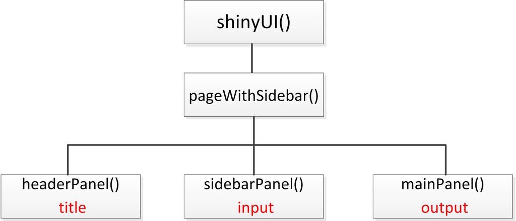

# 第二節：簡單介紹shiny app架構(3)

- 下列是剛剛你所貼上的程式碼(server.R)

```r
library(shiny)

# Define server logic required to generate and plot a random distribution
shinyServer(function(input, output) {

    # Expression that generates a plot of the distribution. The expression is
    # wrapped in a call to renderPlot to indicate that:
    #
    # 1) It is 'reactive' and therefore should be automatically re-executed
    # when inputs change 2) Its output type is a plot
    output$distPlot = renderPlot({

        # generate an rnorm distribution and plot it
        dist = rnorm(input$obs)
        hist(dist)
    })

})
```

- 其中是以shinyServer()這個函數為開頭，裡面包含著一個函數function()要求你指定input及output，由於我們只要做一個反應函數，由於我們想要畫一張圖，所以使用renderPlot()函數，在裡面我們指定它畫圖的過程，並且將結果儲存在output裡面的distPlot。
- 這個畫圖的過程很簡單，就是先指定一個數字（由input$obs提供，也就是剛剛在ui.R中使用者所給定的參數)，然後要求R使用rnorm()隨機產生n個平均數為0，標準差為1的數列，而這個數列儲存在dist元件內。接著在以hist(dist)畫出這個數列的直方圖。
- 因此，在renderPlot()函數內，我們根據使用者指定的參數(input$obs)產生了一張直方圖，而這張直方圖將會儲存在output裡面的distPlot。
- 接著這個物件distPlot就會回到ui.R中，而根據我們在ui.R中所下的指令，他將會使用plotOutput()函數使這張圖形呈現在輸出區上。

Note：所有的輸入元件都存取在input這個List內；而所有的輸出元件都存取在output這個List內。

# 第二節：簡單介紹shiny app架構(4)

- 至此為止，我們已經學會了webApp的基本寫法。然而這時候若需要進一步的增加它的應用面，我們需要的是學習更多R裡面的函數，讓我們的App可以擁有更強大的功能。
- 請在R內練習下列這段程式碼的使用，並試圖改變裡面的obs,M,S,Coler的數字，了解他的功能

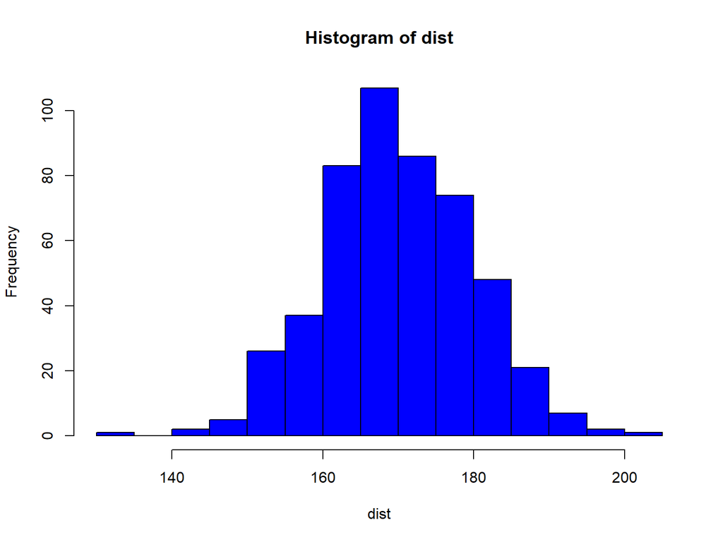

```r
        obs = 500
        M = 170
        S = 10
        Coler = "blue"
        dist = rnorm(obs,mean=M,sd=S)
        hist(dist,col=Coler)
```

# 第二節：簡單介紹shiny app架構(5)

- 在剛剛的練習中我們已經清楚了在R裡面，改變參數可以改變圖形的常態分布，接著我們可以開始增加這些參數至我們剛剛寫的App內。
- 除了已經存在的obs之外，我們將繼續增加M,S,Coler在我們的控制區域之內。
- ui.R

```r
library(shiny)

# Define UI for application that plots random distributions
shinyUI(pageWithSidebar(

  # Application title
  headerPanel("Hello Shiny!"),

  # Sidebar with inputs for number of observations, mean, SD, and coler.
  sidebarPanel(
    sliderInput("obs", "Number of observations:", min = 0, max = 1000, value = 500),
    numericInput("M", "Mean of this normal distribution:", min = -200, max = 200, value = 100),
    numericInput("S", "SD of this normal distribution:", min = 0, max = 50, value = 10),
    radioButtons("Color", "Select the color of histogram:", choices = c("Red" = "red", "Blue" = "blue", "Green" = "green"))
  ),

  # Show a plot of the generated distribution
  mainPanel(
    plotOutput("distPlot")
  )
))
```

- server.R (注意在server.R之中，所有在ui.R內所出現的參數前面都要加上”input$“，表示他其實是在input這個List之內的東西。)

```r
library(shiny)

# Define server logic required to generate and plot a random distribution
shinyServer(function(input, output) {

    # Expression that generates a plot of the distribution. The expression is
    # wrapped in a call to renderPlot to indicate that:
    #
    # 1) It is 'reactive' and therefore should be automatically re-executed
    # when inputs change 2) Its output type is a plot
    output$distPlot = renderPlot({

        # generate an rnorm distribution and plot it
        dist = rnorm(input$obs,mean=input$M,sd=input$S)
        hist(dist,col=input$Color)
    })

})
```

# 第三節：自訂函數與shiny app(1)

- 我們先把R做為一個計算機來使用，並且使用函數功能做一些較複雜的運算。
- 下面這個範例，是試著計算出在進行民調抽樣時的樣本數估計，假定我們可以接受的誤差為3%，我們將可以透過下列公式計算出所需樣本數(X=可接受的誤差值；p=預期的支持率；Z=可接受之信賴區間對應之Z值)

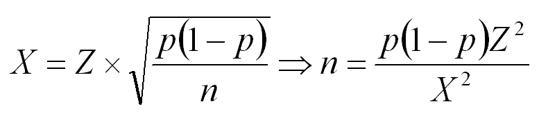

```r
Sig = 0.05  #two-sided significance level
p = 0.5     #The expected rate
X = 0.03    #Acceptable error range
Z = qnorm(1-Sig/2)   #The Z value based on the two-sided significance level
n = p*(1-p)*Z^2/X^2  #Calculate the needed number of sample
n           #Print the outcome
```

- 接著，我們可以把它包為一個函數(請試試它的功能)

```r
Samplesize = function(Sig,p,X) {
  Z = qnorm(1-Sig/2)
  n = p*(1-p)*Z^2/X^2
  n
}

Samplesize(Sig = 0.05,p = 0.5, X = 0.03) #Test 1
Samplesize(Sig = 0.05,p = 0.2, X = 0.03) #Test 2
Samplesize(Sig = 0.05,p = 0.2, X = 0.05) #Test 3
```

# 第三節：自訂函數與shiny app(2)

- 在R裡面我們學會函數運算之後，接著我們會希望其他人也可以輕易的使用我們剛剛設定好的函數，因此我們會希望將他寫成像這樣子的App，供大家使用。
- ui.R

```r
library(shiny)

# Define UI for application that calculate the needed sample size
shinyUI(pageWithSidebar(

  # Application title
  headerPanel("Sample size calculator"),

  # Sidebar with numeric inputs for significance level, expected rate, acceptable error range.
  sidebarPanel(
    numericInput("Sig", "Two-sided significance level:", min = 0, max = 1.000, value = 0.05),
    numericInput("p", "The expected rate:", min = 0, max = 1, value = 0.5),
    numericInput("X", "Acceptable error range:", min = 0, max = 1, value = 0.03)
  ),

  # Show the outcome
  mainPanel(
    h3(textOutput("Size"))
  )
))
```

- server.R

```r
library(shiny)

# Your function
Samplesize = function(Sig,p,X) {
  Z = qnorm(1-Sig/2)
  n = p*(1-p)*Z^2/X^2
  n
}

# Define server logic required to calculate the needed sample size
shinyServer(function(input, output) {

    output$Size = renderText({
      N = Samplesize(Sig = input$Sig,p = input$p, X = input$X)
      paste("We need",round(N),"samples for this sampling.")
    })

})
```

# 練習-2

- 下列公式是Case control study所需要的樣本數估計公式，如果可以的話，請試著建立函數計算Sample size，並且建立在App內

– 原始參數共有5個，分別是:

1. alpha: 雙尾顯著水準（請在運算前把它轉換為適當的Z value）
2. power: 單尾檢力（請在運算前把它轉換為適當的Z value）
3. OR: 臨床上有意義之最小OR
4. r: Case組人數是Control組人數的幾倍
5. p0: 預期Control組之暴露率

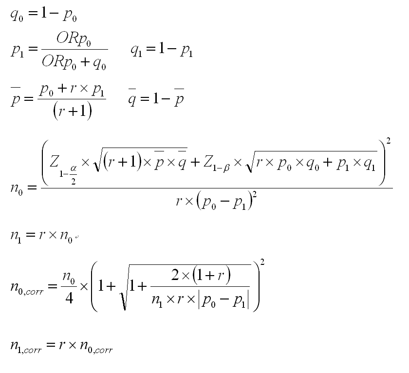

- 如果你真的無法自己寫出上述公式，那請你複製下列這串程式碼

```r
Samplesize_OR = function(alpha,power,OR,r,p0,corr=FALSE) {
  Za=qnorm(1-alpha/2)
  Zb=qnorm(power)
  q0=1-p0
  p1=OR*p0/(OR*p0+q0)
  q1=1-p1
  pbar=(p0+r*p1)/(r+1)
  qbar=1-pbar
  n0=(Za*sqrt((r+1)*pbar*qbar)+Zb*sqrt(r*p0*q0+p1*q1))^2/(r*(p0-p1)^2)
  n1=r*n0
  n0corr=n0/4*(1+sqrt(1+(2*(1+r)/(n1*r*sqrt((p0-p1)^2)))))^2
  n1corr=r*n0corr
  if (corr==FALSE) {return(paste("Control:",round(n0)+1,"; Case:",round(n1)+1,"; Total:",round(n0)+round(n1)+2,sep=""))}
  if (corr==TRUE) {return(paste("Control:",round(n0corr)+1,"; Case:",round(n1corr)+1,"; Total:",round(n0corr)+round(n1corr)+2,sep=""))}
}

Samplesize_OR(alpha=0.05,power=0.8,OR=1.5,r=1,p0=0.2,corr=FALSE)
Samplesize_OR(alpha=0.05,power=0.8,OR=1.5,r=1,p0=0.2,corr=TRUE)
```

# 練習-2 答案

- ui.R

```r
library(shiny)

shinyUI(pageWithSidebar(

  headerPanel("Sample size for Case Control study"),

  sidebarPanel(
    numericInput("alpha", "Two-sided significance level:", min = 0.001, max = 0.999, value = 0.05),
    numericInput("power", "Power:", min = 0.001, max = 0.999, value = 0.8),
    numericInput("OR", "Smallest difference of clinical/biological importance:", min = 0.01, max = 100, value = 1.5),
    numericInput("r", "The ratio of Case/Control:", min = 0.01, max = 100, value = 1),
    numericInput("p0", "Proportion of controls with exposures:", min = 0.001, max = 0.999, value = 0.2)
  ),

  mainPanel(
    h3(textOutput("text1")),
    h4(textOutput("text2")),
    h3(textOutput("text3")),
    h4(textOutput("text4"))
  )
))
```

- server.R

```r
library(shiny)

Samplesize_OR = function(alpha,power,OR,r,p0,corr=FALSE) {
  Za=qnorm(1-alpha/2)
  Zb=qnorm(power)
  q0=1-p0
  p1=OR*p0/(OR*p0+q0)
  q1=1-p1
  pbar=(p0+r*p1)/(r+1)
  qbar=1-pbar
  n0=(Za*sqrt((r+1)*pbar*qbar)+Zb*sqrt(r*p0*q0+p1*q1))^2/(r*(p0-p1)^2)
  n1=r*n0
  n0corr=n0/4*(1+sqrt(1+(2*(1+r)/(n1*r*sqrt((p0-p1)^2)))))^2
  n1corr=r*n0corr
  if (corr==FALSE) {return(paste("Control:",round(n0)+1,"; Case:",round(n1)+1,"; Total:",round(n0)+round(n1)+2,sep=""))}
  if (corr==TRUE) {return(paste("Control:",round(n0corr)+1,"; Case:",round(n1corr)+1,"; Total:",round(n0corr)+round(n1corr)+2,sep=""))}
}

shinyServer(function(input, output) {

  output$text1 = renderText({
    "Sample size without continuity correction:"
  })

  output$text2 = renderText({
    Samplesize_OR(alpha=input$alpha,power=input$power,OR=input$OR,r=input$r,p0=input$p0)
  })

  output$text3 = renderText({
    "Sample size with continuity correction:"
  })

  output$text4 = renderText({
    Samplesize_OR(alpha=input$alpha,power=input$power,OR=input$OR,r=input$r,p0=input$p0,corr=TRUE)
  })

})
```

# 第四節：conditionalPanel的應用(1)

- 如果可以的話，我們會更希望兩種計算工具可以合在同個App內，那我們在ui.R中會需要一個新的函數，叫做conditionalPanel()

– conditionalPanel()可以讓我們的控制bar僅在特定條件下出現

- 這邊有個範例，設計一個按鈕選擇我要產生常態分布還是t分佈

– 常態分布必須要有兩個參數(平均數&標準差)決定，而t分布則必須要由一個參數決定(自由度)，因此我們就必須設計當選擇常態分不時，控制區要出現的是平均數&標準差；若選擇了t分布，控制區要出現的則是自由度

- ui.R

```r
library(shiny)
shinyUI(pageWithSidebar(

  headerPanel("Generating distribution"),

  sidebarPanel(
    selectInput("method", "Choose distribution:", choices=c("Normal"="norm", "Student t"="st")),
    helpText("Setting parameter(s) for distribution model"),
    conditionalPanel(condition="input.method=='norm'",
                     numericInput(inputId="mu", label="mean", value=0),
                     numericInput(inputId="sd", label="standard deviation", value=1, min=0)
    ),
    conditionalPanel(condition="input.method=='st'",
                     numericInput(inputId="df", label="Df", value=10, min=1)
    ),
    sliderInput(inputId="obs",
                label="Number of observations:",
                min = 1, max = 1000, value = 500)
  ),

  mainPanel(
    plotOutput("distPlot")
  )

))
```

- server.R

```r
library(shiny)

shinyServer(function(input, output) {
    output$distPlot <- renderPlot({
        if (input$method == "norm")
            {dist <- rnorm(input$obs, mean = input$mu, sd = input$sd)}
        if (input$method == "st")
            {dist <- rt(input$obs, df = input$df)}
        hist(dist)
    })
})
```

# 練習-3

- 請試著使用conditionalPanel()，將剛剛練習中的兩種樣本數估計的方式寫在同個App之內，並讓使用者自行選擇。

# 練習-3 答案

- ui.R

```r
library(shiny)

shinyUI(pageWithSidebar(

  headerPanel("Sample size calculator"),

  sidebarPanel(
    selectInput("method", "Choose a method:", choices=c("Rate"="rate", "Case Control Study"="cc")),
    conditionalPanel(condition="input.method=='rate'",
    numericInput("Sig", "Two-sided significance level:", min = 0, max = 1.000, value = 0.05),
    numericInput("p", "The expected rate:", min = 0, max = 1, value = 0.5),
    numericInput("X", "Acceptable error range:", min = 0, max = 1, value = 0.03)
    ),
    conditionalPanel(condition="input.method=='cc'",
    numericInput("alpha", "Two-sided significance level:", min = 0.001, max = 0.999, value = 0.05),
    numericInput("power", "Power:", min = 0.001, max = 0.999, value = 0.8),
    numericInput("OR", "Smallest difference of clinical/biological importance:", min = 0.01, max = 100, value = 1.5),
    numericInput("r", "The ratio of Case/Control:", min = 0.01, max = 100, value = 1),
    numericInput("p0", "Proportion of controls with exposures:", min = 0.001, max = 0.999, value = 0.2)
    )
  ),

  mainPanel(
    h3(textOutput("text1")),
    h4(textOutput("text2")),
    h3(textOutput("text3")),
    h4(textOutput("text4"))
  )
))
```

- server.R

```r
library(shiny)

Samplesize = function(Sig,p,X) {
  Z = qnorm(1-Sig/2)
  n = p*(1-p)*Z^2/X^2
  n
}

Samplesize_OR = function(alpha,power,OR,r,p0,corr=FALSE) {
  Za=qnorm(1-alpha/2)
  Zb=qnorm(power)
  q0=1-p0
  p1=OR*p0/(OR*p0+q0)
  q1=1-p1
  pbar=(p0+r*p1)/(r+1)
  qbar=1-pbar
  n0=(Za*sqrt((r+1)*pbar*qbar)+Zb*sqrt(r*p0*q0+p1*q1))^2/(r*(p0-p1)^2)
  n1=r*n0
  n0corr=n0/4*(1+sqrt(1+(2*(1+r)/(n1*r*sqrt((p0-p1)^2)))))^2
  n1corr=r*n0corr
  if (corr==FALSE) {return(paste("Control:",round(n0)+1,"; Case:",round(n1)+1,"; Total:",round(n0)+round(n1)+2,sep=""))}
  if (corr==TRUE) {return(paste("Control:",round(n0corr)+1,"; Case:",round(n1corr)+1,"; Total:",round(n0corr)+round(n1corr)+2,sep=""))}
}

shinyServer(function(input, output) {

  output$text1 = renderText({
    if (input$method=="rate") {
      N = Samplesize(Sig = input$Sig,p = input$p, X = input$X)
      return(paste("We need",round(N),"samples for this sampling."))
     }
    if (input$method=="cc") {"Sample size without continuity correction:"}
  })

  output$text2 = renderText({
    if (input$method=="rate") {return(NULL)}
    if (input$method=="cc") {Samplesize_OR(alpha=input$alpha,power=input$power,OR=input$OR,r=input$r,p0=input$p0)}
  })

  output$text3 = renderText({
    if (input$method=="rate") {return(NULL)}
    if (input$method=="cc") {"Sample size with continuity correction:"}
  })

  output$text4 = renderText({
    if (input$method=="rate") {return(NULL)}
    if (input$method=="cc") {Samplesize_OR(alpha=input$alpha,power=input$power,OR=input$OR,r=input$r,p0=input$p0,corr=TRUE)}
  })

})
```

# 小結

- 今天的課程教了幾項重點，請大家有空多多練習：
1. 撰寫App(ui.R以及server.R)
2. 在R內自創函數
3. 利用conditionalPanel()增加使用者介面的自由度
- 我們之後會一步一步的教大家如何將你寫的函數套用到這個webApp上！